# Risk Factor Analysis

## Outcome Variable

**Outcome Variable:** swasted

## Predictor Variables

**Intervention Variable:** mhtcm

**Adjustment Set:**

- arm
- W_mage
- meducyrs
- feducyrs
- single
- delta_W_mage
- delta_meducyrs
- delta_feducyrs
- delta_single

## Stratifying Variables

The analysis was stratified on these variable(s):

- agecat
- studyid
- country

## Data Summary

| agecat | studyid | country | mhtcm | swasted | n_cell | n |
| --- | --- | --- | --- | --- | --- | --- |
| Birth | ki0047075b-MAL-ED | BANGLADESH | >=155 cm | 0 | 21 | 209 |
| Birth | ki0047075b-MAL-ED | BANGLADESH | >=155 cm | 1 | 0 | 209 |
| Birth | ki0047075b-MAL-ED | BANGLADESH | <151 cm | 0 | 129 | 209 |
| Birth | ki0047075b-MAL-ED | BANGLADESH | <151 cm | 1 | 5 | 209 |
| Birth | ki0047075b-MAL-ED | BANGLADESH | [151-155) cm | 0 | 51 | 209 |
| Birth | ki0047075b-MAL-ED | BANGLADESH | [151-155) cm | 1 | 3 | 209 |
| Birth | ki0047075b-MAL-ED | BRAZIL | >=155 cm | 0 | 32 | 61 |
| Birth | ki0047075b-MAL-ED | BRAZIL | >=155 cm | 1 | 0 | 61 |
| Birth | ki0047075b-MAL-ED | BRAZIL | <151 cm | 0 | 19 | 61 |
| Birth | ki0047075b-MAL-ED | BRAZIL | <151 cm | 1 | 0 | 61 |
| Birth | ki0047075b-MAL-ED | BRAZIL | [151-155) cm | 0 | 10 | 61 |
| Birth | ki0047075b-MAL-ED | BRAZIL | [151-155) cm | 1 | 0 | 61 |
| Birth | ki0047075b-MAL-ED | INDIA | >=155 cm | 0 | 11 | 41 |
| Birth | ki0047075b-MAL-ED | INDIA | >=155 cm | 1 | 0 | 41 |
| Birth | ki0047075b-MAL-ED | INDIA | <151 cm | 0 | 19 | 41 |
| Birth | ki0047075b-MAL-ED | INDIA | <151 cm | 1 | 0 | 41 |
| Birth | ki0047075b-MAL-ED | INDIA | [151-155) cm | 0 | 11 | 41 |
| Birth | ki0047075b-MAL-ED | INDIA | [151-155) cm | 1 | 0 | 41 |
| Birth | ki0047075b-MAL-ED | NEPAL | >=155 cm | 0 | 6 | 26 |
| Birth | ki0047075b-MAL-ED | NEPAL | >=155 cm | 1 | 0 | 26 |
| Birth | ki0047075b-MAL-ED | NEPAL | <151 cm | 0 | 12 | 26 |
| Birth | ki0047075b-MAL-ED | NEPAL | <151 cm | 1 | 1 | 26 |
| Birth | ki0047075b-MAL-ED | NEPAL | [151-155) cm | 0 | 7 | 26 |
| Birth | ki0047075b-MAL-ED | NEPAL | [151-155) cm | 1 | 0 | 26 |
| Birth | ki0047075b-MAL-ED | PERU | >=155 cm | 0 | 47 | 221 |
| Birth | ki0047075b-MAL-ED | PERU | >=155 cm | 1 | 0 | 221 |
| Birth | ki0047075b-MAL-ED | PERU | <151 cm | 0 | 127 | 221 |
| Birth | ki0047075b-MAL-ED | PERU | <151 cm | 1 | 0 | 221 |
| Birth | ki0047075b-MAL-ED | PERU | [151-155) cm | 0 | 47 | 221 |
| Birth | ki0047075b-MAL-ED | PERU | [151-155) cm | 1 | 0 | 221 |

[output cut: 324 more lines]

The following strata were considered:

- agecat: 24 months, studyid: ki0047075b-MAL-ED, country: BANGLADESH
- agecat: 24 months, studyid: ki0047075b-MAL-ED, country: BRAZIL
- agecat: 24 months, studyid: ki0047075b-MAL-ED, country: INDIA
- agecat: 24 months, studyid: ki0047075b-MAL-ED, country: NEPAL
- agecat: 24 months, studyid: ki0047075b-MAL-ED, country: PERU
- agecat: 24 months, studyid: ki0047075b-MAL-ED, country: SOUTH AFRICA
- agecat: 24 months, studyid: ki0047075b-MAL-ED, country: TANZANIA, UNITED REPUBLIC OF
- agecat: 24 months, studyid: ki1017093-NIH-Birth, country: BANGLADESH
- agecat: 24 months, studyid: ki1017093b-PROVIDE, country: BANGLADESH
- agecat: 24 months, studyid: ki1017093c-NIH-Crypto, country: BANGLADESH
- agecat: 24 months, studyid: ki1066203-TanzaniaChild2, country: TANZANIA, UNITED REPUBLIC OF
- agecat: 24 months, studyid: ki1101329-Keneba, country: GAMBIA
- agecat: 24 months, studyid: ki1119695-PROBIT, country: BELARUS
- agecat: 24 months, studyid: ki1126311-ZVITAMBO, country: ZIMBABWE
- agecat: 24 months, studyid: ki1135781-COHORTS, country: GUATEMALA
- agecat: 24 months, studyid: ki1135781-COHORTS, country: INDIA
- agecat: 24 months, studyid: ki1135781-COHORTS, country: PHILIPPINES
- agecat: 24 months, studyid: ki1148112-LCNI-5, country: MALAWI
- agecat: 24 months, studyid: kiGH5241-JiVitA-3, country: BANGLADESH
- agecat: 6 months, studyid: ki0047075b-MAL-ED, country: BANGLADESH
- agecat: 6 months, studyid: ki0047075b-MAL-ED, country: BRAZIL
- agecat: 6 months, studyid: ki0047075b-MAL-ED, country: INDIA
- agecat: 6 months, studyid: ki0047075b-MAL-ED, country: NEPAL
- agecat: 6 months, studyid: ki0047075b-MAL-ED, country: PERU
- agecat: 6 months, studyid: ki0047075b-MAL-ED, country: SOUTH AFRICA
- agecat: 6 months, studyid: ki0047075b-MAL-ED, country: TANZANIA, UNITED REPUBLIC OF
- agecat: 6 months, studyid: ki1000304b-SAS-CompFeed, country: INDIA
- agecat: 6 months, studyid: ki1000304b-SAS-FoodSuppl, country: INDIA
- agecat: 6 months, studyid: ki1017093-NIH-Birth, country: BANGLADESH
- agecat: 6 months, studyid: ki1017093b-PROVIDE, country: BANGLADESH
- agecat: 6 months, studyid: ki1017093c-NIH-Crypto, country: BANGLADESH
- agecat: 6 months, studyid: ki1066203-TanzaniaChild2, country: TANZANIA, UNITED REPUBLIC OF
- agecat: 6 months, studyid: ki1101329-Keneba, country: GAMBIA
- agecat: 6 months, studyid: ki1112895-Guatemala BSC, country: GUATEMALA
- agecat: 6 months, studyid: ki1119695-PROBIT, country: BELARUS
- agecat: 6 months, studyid: ki1126311-ZVITAMBO, country: ZIMBABWE
- agecat: 6 months, studyid: ki1135781-COHORTS, country: GUATEMALA
- agecat: 6 months, studyid: ki1135781-COHORTS, country: INDIA
- agecat: 6 months, studyid: ki1135781-COHORTS, country: PHILIPPINES
- agecat: 6 months, studyid: ki1148112-LCNI-5, country: MALAWI
- agecat: 6 months, studyid: kiGH5241-JiVitA-3, country: BANGLADESH
- agecat: Birth, studyid: ki0047075b-MAL-ED, country: BANGLADESH
- agecat: Birth, studyid: ki0047075b-MAL-ED, country: BRAZIL
- agecat: Birth, studyid: ki0047075b-MAL-ED, country: INDIA
- agecat: Birth, studyid: ki0047075b-MAL-ED, country: NEPAL
- agecat: Birth, studyid: ki0047075b-MAL-ED, country: PERU
- agecat: Birth, studyid: ki0047075b-MAL-ED, country: SOUTH AFRICA
- agecat: Birth, studyid: ki0047075b-MAL-ED, country: TANZANIA, UNITED REPUBLIC OF
- agecat: Birth, studyid: ki1000304b-SAS-CompFeed, country: INDIA
- agecat: Birth, studyid: ki1017093-NIH-Birth, country: BANGLADESH
- agecat: Birth, studyid: ki1017093b-PROVIDE, country: BANGLADESH
- agecat: Birth, studyid: ki1017093c-NIH-Crypto, country: BANGLADESH
- agecat: Birth, studyid: ki1101329-Keneba, country: GAMBIA
- agecat: Birth, studyid: ki1119695-PROBIT, country: BELARUS
- agecat: Birth, studyid: ki1126311-ZVITAMBO, country: ZIMBABWE
- agecat: Birth, studyid: ki1135781-COHORTS, country: GUATEMALA
- agecat: Birth, studyid: ki1135781-COHORTS, country: INDIA
- agecat: Birth, studyid: ki1135781-COHORTS, country: PHILIPPINES
- agecat: Birth, studyid: kiGH5241-JiVitA-3, country: BANGLADESH

### Dropped Strata

Some strata were dropped due to rare outcomes:

- agecat: Birth, studyid: ki0047075b-MAL-ED, country: BANGLADESH
- agecat: Birth, studyid: ki0047075b-MAL-ED, country: BRAZIL
- agecat: Birth, studyid: ki0047075b-MAL-ED, country: INDIA
- agecat: Birth, studyid: ki0047075b-MAL-ED, country: NEPAL
- agecat: Birth, studyid: ki0047075b-MAL-ED, country: PERU
- agecat: Birth, studyid: ki0047075b-MAL-ED, country: SOUTH AFRICA
- agecat: Birth, studyid: ki0047075b-MAL-ED, country: TANZANIA, UNITED REPUBLIC OF
- agecat: Birth, studyid: ki1017093-NIH-Birth, country: BANGLADESH
- agecat: Birth, studyid: ki1017093b-PROVIDE, country: BANGLADESH
- agecat: Birth, studyid: ki1101329-Keneba, country: GAMBIA
- agecat: 6 months, studyid: ki0047075b-MAL-ED, country: BANGLADESH
- agecat: 6 months, studyid: ki0047075b-MAL-ED, country: BRAZIL
- agecat: 6 months, studyid: ki0047075b-MAL-ED, country: INDIA
- agecat: 6 months, studyid: ki0047075b-MAL-ED, country: NEPAL
- agecat: 6 months, studyid: ki0047075b-MAL-ED, country: PERU
- agecat: 6 months, studyid: ki0047075b-MAL-ED, country: SOUTH AFRICA
- agecat: 6 months, studyid: ki0047075b-MAL-ED, country: TANZANIA, UNITED REPUBLIC OF
- agecat: 6 months, studyid: ki1000304b-SAS-FoodSuppl, country: INDIA
- agecat: 6 months, studyid: ki1017093-NIH-Birth, country: BANGLADESH
- agecat: 6 months, studyid: ki1017093b-PROVIDE, country: BANGLADESH
- agecat: 6 months, studyid: ki1017093c-NIH-Crypto, country: BANGLADESH
- agecat: 6 months, studyid: ki1066203-TanzaniaChild2, country: TANZANIA, UNITED REPUBLIC OF
- agecat: 6 months, studyid: ki1101329-Keneba, country: GAMBIA
- agecat: 6 months, studyid: ki1112895-Guatemala BSC, country: GUATEMALA
- agecat: 6 months, studyid: ki1119695-PROBIT, country: BELARUS
- agecat: 6 months, studyid: ki1135781-COHORTS, country: GUATEMALA
- agecat: 6 months, studyid: ki1148112-LCNI-5, country: MALAWI
- agecat: 24 months, studyid: ki0047075b-MAL-ED, country: BANGLADESH
- agecat: 24 months, studyid: ki0047075b-MAL-ED, country: BRAZIL
- agecat: 24 months, studyid: ki0047075b-MAL-ED, country: INDIA
- agecat: 24 months, studyid: ki0047075b-MAL-ED, country: NEPAL
- agecat: 24 months, studyid: ki0047075b-MAL-ED, country: PERU
- agecat: 24 months, studyid: ki0047075b-MAL-ED, country: SOUTH AFRICA
- agecat: 24 months, studyid: ki0047075b-MAL-ED, country: TANZANIA, UNITED REPUBLIC OF
- agecat: 24 months, studyid: ki1017093-NIH-Birth, country: BANGLADESH
- agecat: 24 months, studyid: ki1017093b-PROVIDE, country: BANGLADESH
- agecat: 24 months, studyid: ki1017093c-NIH-Crypto, country: BANGLADESH
- agecat: 24 months, studyid: ki1066203-TanzaniaChild2, country: TANZANIA, UNITED REPUBLIC OF
- agecat: 24 months, studyid: ki1101329-Keneba, country: GAMBIA
- agecat: 24 months, studyid: ki1119695-PROBIT, country: BELARUS
- agecat: 24 months, studyid: ki1126311-ZVITAMBO, country: ZIMBABWE
- agecat: 24 months, studyid: ki1135781-COHORTS, country: GUATEMALA
- agecat: 24 months, studyid: ki1135781-COHORTS, country: INDIA
- agecat: 24 months, studyid: ki1135781-COHORTS, country: PHILIPPINES
- agecat: 24 months, studyid: ki1148112-LCNI-5, country: MALAWI

## Methods Detail

We’re interested in the causal parameters $E[Y_a]$ for all values of $a \in \mathcal{A}$. These parameters represent the mean outcome if, possibly contrary to fact, we intervened to set all units to have $A=a$. Under the randomization and positivity assumptions, these are identified by the statistical parameters $\psi_a=E_W[E_{Y|A,W}(Y|A=a,W)]$. In addition, we’re interested in the mean of $Y$, $E[Y]$ under no intervention (the observed mean). We will estimate these parameters by using SuperLearner to fit the relevant likelihood factors – $E_{Y|A,W}(Y|A=a,W)$ and $p(A=a|W)$, and then updating our likelihood fit using a joint TMLE.

For unadjusted analyses ($W=\{\}$), initial likelihoods were estimated using Lrnr_glm to estimate the simple $E(Y|A)$ and Lrnr_mean to estimate $p(A)$. For adjusted analyses, a small library containing Lrnr_glmnet, Lrnr_xgboost, and Lrnr_mean was used.

Having estimated these parameters, we will then use the delta method to estimate relative risks and attributable risks relative to a prespecified baseline level of $A$.

# Results Detail

## Results Plots

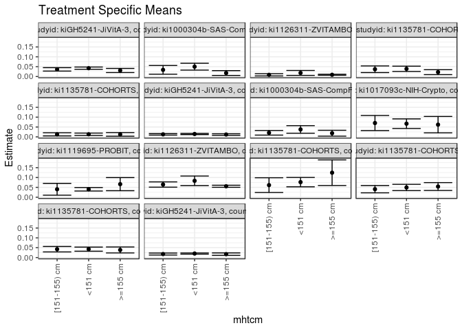

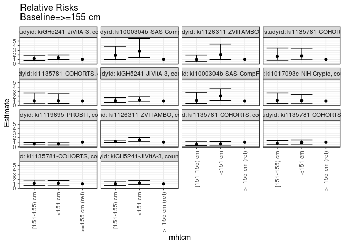

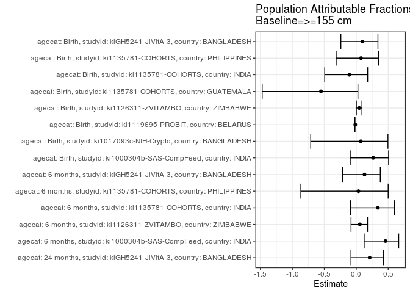

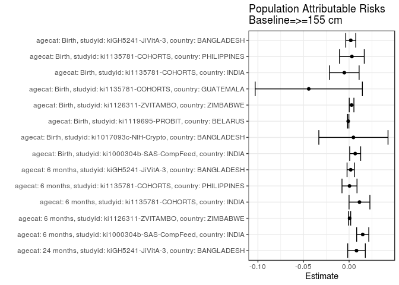

## Results Table

### Parameter: TSM

| agecat | studyid | country | intervention_level | baseline_level | estimate | ci_lower | ci_upper |
| --- | --- | --- | --- | --- | --- | --- | --- |
| Birth | ki1000304b-SAS-CompFeed | INDIA | >=155 cm | NA | 0.0185185 | 0.0036666 | 0.0333705 |
| Birth | ki1000304b-SAS-CompFeed | INDIA | <151 cm | NA | 0.0376176 | 0.0183457 | 0.0568894 |
| Birth | ki1000304b-SAS-CompFeed | INDIA | [151-155) cm | NA | 0.0207469 | 0.0089754 | 0.0325184 |
| Birth | ki1017093c-NIH-Crypto | BANGLADESH | >=155 cm | NA | 0.0620155 | 0.0203660 | 0.1036650 |
| Birth | ki1017093c-NIH-Crypto | BANGLADESH | <151 cm | NA | 0.0668317 | 0.0424627 | 0.0912007 |
| Birth | ki1017093c-NIH-Crypto | BANGLADESH | [151-155) cm | NA | 0.0701754 | 0.0318619 | 0.1084889 |
| Birth | ki1119695-PROBIT | BELARUS | >=155 cm | NA | 0.0662408 | 0.0329778 | 0.0995037 |
| Birth | ki1119695-PROBIT | BELARUS | <151 cm | NA | 0.0403226 | 0.0314227 | 0.0492225 |
| Birth | ki1119695-PROBIT | BELARUS | [151-155) cm | NA | 0.0403023 | 0.0103909 | 0.0702137 |
| Birth | ki1126311-ZVITAMBO | ZIMBABWE | >=155 cm | NA | 0.0555701 | 0.0502984 | 0.0608418 |
| Birth | ki1126311-ZVITAMBO | ZIMBABWE | <151 cm | NA | 0.0833001 | 0.0590243 | 0.1075759 |
| Birth | ki1126311-ZVITAMBO | ZIMBABWE | [151-155) cm | NA | 0.0644244 | 0.0510857 | 0.0777630 |
| Birth | ki1135781-COHORTS | GUATEMALA | >=155 cm | NA | 0.1244567 | 0.0594468 | 0.1894667 |
| Birth | ki1135781-COHORTS | GUATEMALA | <151 cm | NA | 0.0765494 | 0.0528171 | 0.1002817 |
| Birth | ki1135781-COHORTS | GUATEMALA | [151-155) cm | NA | 0.0613896 | 0.0241264 | 0.0986529 |
| Birth | ki1135781-COHORTS | INDIA | >=155 cm | NA | 0.0541850 | 0.0342928 | 0.0740772 |
| Birth | ki1135781-COHORTS | INDIA | <151 cm | NA | 0.0494496 | 0.0335240 | 0.0653751 |
| Birth | ki1135781-COHORTS | INDIA | [151-155) cm | NA | 0.0407505 | 0.0222390 | 0.0592621 |
| Birth | ki1135781-COHORTS | PHILIPPINES | >=155 cm | NA | 0.0386535 | 0.0235394 | 0.0537675 |
| Birth | ki1135781-COHORTS | PHILIPPINES | <151 cm | NA | 0.0427637 | 0.0322991 | 0.0532283 |
| Birth | ki1135781-COHORTS | PHILIPPINES | [151-155) cm | NA | 0.0425639 | 0.0286742 | 0.0564536 |
| Birth | kiGH5241-JiVitA-3 | BANGLADESH | >=155 cm | NA | 0.0175104 | 0.0113798 | 0.0236410 |
| Birth | kiGH5241-JiVitA-3 | BANGLADESH | <151 cm | NA | 0.0205190 | 0.0175283 | 0.0235097 |
| Birth | kiGH5241-JiVitA-3 | BANGLADESH | [151-155) cm | NA | 0.0178826 | 0.0127750 | 0.0229902 |
| 6 months | ki1000304b-SAS-CompFeed | INDIA | >=155 cm | NA | 0.0176817 | 0.0055394 | 0.0298241 |
| 6 months | ki1000304b-SAS-CompFeed | INDIA | <151 cm | NA | 0.0498812 | 0.0325212 | 0.0672413 |
| 6 months | ki1000304b-SAS-CompFeed | INDIA | [151-155) cm | NA | 0.0337838 | 0.0116352 | 0.0559323 |
| 6 months | ki1126311-ZVITAMBO | ZIMBABWE | >=155 cm | NA | 0.0088235 | 0.0064125 | 0.0112346 |
| 6 months | ki1126311-ZVITAMBO | ZIMBABWE | <151 cm | NA | 0.0181818 | 0.0056969 | 0.0306667 |
| 6 months | ki1126311-ZVITAMBO | ZIMBABWE | [151-155) cm | NA | 0.0085714 | 0.0029952 | 0.0141477 |
| 6 months | ki1135781-COHORTS | INDIA | >=155 cm | NA | 0.0221626 | 0.0097575 | 0.0345676 |
| 6 months | ki1135781-COHORTS | INDIA | <151 cm | NA | 0.0390033 | 0.0254447 | 0.0525619 |
| 6 months | ki1135781-COHORTS | INDIA | [151-155) cm | NA | 0.0368886 | 0.0200568 | 0.0537204 |
| 6 months | ki1135781-COHORTS | PHILIPPINES | >=155 cm | NA | 0.0125000 | 0.0032964 | 0.0217036 |
| 6 months | ki1135781-COHORTS | PHILIPPINES | <151 cm | NA | 0.0131579 | 0.0071184 | 0.0191974 |
| 6 months | ki1135781-COHORTS | PHILIPPINES | [151-155) cm | NA | 0.0128535 | 0.0049369 | 0.0207701 |
| 6 months | kiGH5241-JiVitA-3 | BANGLADESH | >=155 cm | NA | 0.0119122 | 0.0077997 | 0.0160247 |
| 6 months | kiGH5241-JiVitA-3 | BANGLADESH | <151 cm | NA | 0.0145666 | 0.0116821 | 0.0174511 |
| 6 months | kiGH5241-JiVitA-3 | BANGLADESH | [151-155) cm | NA | 0.0127388 | 0.0089118 | 0.0165658 |
| 24 months | kiGH5241-JiVitA-3 | BANGLADESH | >=155 cm | NA | 0.0306052 | 0.0202052 | 0.0410051 |
| 24 months | kiGH5241-JiVitA-3 | BANGLADESH | <151 cm | NA | 0.0422458 | 0.0364194 | 0.0480722 |
| 24 months | kiGH5241-JiVitA-3 | BANGLADESH | [151-155) cm | NA | 0.0362636 | 0.0276220 | 0.0449053 |

### Parameter: E(Y)

| agecat | studyid | country | intervention_level | baseline_level | estimate | ci_lower | ci_upper |
| --- | --- | --- | --- | --- | --- | --- | --- |
| Birth | ki1000304b-SAS-CompFeed | INDIA | NA | NA | 0.0252016 | 0.0126376 | 0.0377656 |
| Birth | ki1017093c-NIH-Crypto | BANGLADESH | NA | NA | 0.0667614 | 0.0483100 | 0.0852128 |
| Birth | ki1119695-PROBIT | BELARUS | NA | NA | 0.0652524 | 0.0325055 | 0.0979992 |
| Birth | ki1126311-ZVITAMBO | ZIMBABWE | NA | NA | 0.0582781 | 0.0534540 | 0.0631023 |
| Birth | ki1135781-COHORTS | GUATEMALA | NA | NA | 0.0802139 | 0.0607354 | 0.0996924 |
| Birth | ki1135781-COHORTS | INDIA | NA | NA | 0.0489260 | 0.0385956 | 0.0592564 |
| Birth | ki1135781-COHORTS | PHILIPPINES | NA | NA | 0.0417385 | 0.0344572 | 0.0490198 |
| Birth | kiGH5241-JiVitA-3 | BANGLADESH | NA | NA | 0.0193466 | 0.0169070 | 0.0217861 |
| 6 months | ki1000304b-SAS-CompFeed | INDIA | NA | NA | 0.0326264 | 0.0237765 | 0.0414763 |
| 6 months | ki1126311-ZVITAMBO | ZIMBABWE | NA | NA | 0.0093535 | 0.0071406 | 0.0115664 |
| 6 months | ki1135781-COHORTS | INDIA | NA | NA | 0.0335349 | 0.0252594 | 0.0418104 |
| 6 months | ki1135781-COHORTS | PHILIPPINES | NA | NA | 0.0129342 | 0.0086762 | 0.0171922 |
| 6 months | kiGH5241-JiVitA-3 | BANGLADESH | NA | NA | 0.0136847 | 0.0116040 | 0.0157654 |
| 24 months | kiGH5241-JiVitA-3 | BANGLADESH | NA | NA | 0.0387398 | 0.0343960 | 0.0430836 |

### Parameter: RR

| agecat | studyid | country | intervention_level | baseline_level | estimate | ci_lower | ci_upper |
| --- | --- | --- | --- | --- | --- | --- | --- |
| Birth | ki1000304b-SAS-CompFeed | INDIA | >=155 cm | >=155 cm | 1.0000000 | 1.0000000 | 1.0000000 |
| Birth | ki1000304b-SAS-CompFeed | INDIA | <151 cm | >=155 cm | 2.0313479 | 1.1392130 | 3.6221270 |
| Birth | ki1000304b-SAS-CompFeed | INDIA | [151-155) cm | >=155 cm | 1.1203319 | 0.4420816 | 2.8391675 |
| Birth | ki1017093c-NIH-Crypto | BANGLADESH | >=155 cm | >=155 cm | 1.0000000 | 1.0000000 | 1.0000000 |
| Birth | ki1017093c-NIH-Crypto | BANGLADESH | <151 cm | >=155 cm | 1.0776609 | 0.5018738 | 2.3140340 |
| Birth | ki1017093c-NIH-Crypto | BANGLADESH | [151-155) cm | >=155 cm | 1.1315789 | 0.4762055 | 2.6889043 |
| Birth | ki1119695-PROBIT | BELARUS | >=155 cm | >=155 cm | 1.0000000 | 1.0000000 | 1.0000000 |
| Birth | ki1119695-PROBIT | BELARUS | <151 cm | >=155 cm | 0.6087275 | 0.3716624 | 0.9970050 |
| Birth | ki1119695-PROBIT | BELARUS | [151-155) cm | >=155 cm | 0.6084209 | 0.3884693 | 0.9529092 |
| Birth | ki1126311-ZVITAMBO | ZIMBABWE | >=155 cm | >=155 cm | 1.0000000 | 1.0000000 | 1.0000000 |
| Birth | ki1126311-ZVITAMBO | ZIMBABWE | <151 cm | >=155 cm | 1.4990091 | 1.1032628 | 2.0367119 |
| Birth | ki1126311-ZVITAMBO | ZIMBABWE | [151-155) cm | >=155 cm | 1.1593355 | 0.9232348 | 1.4558146 |
| Birth | ki1135781-COHORTS | GUATEMALA | >=155 cm | >=155 cm | 1.0000000 | 1.0000000 | 1.0000000 |
| Birth | ki1135781-COHORTS | GUATEMALA | <151 cm | >=155 cm | 0.6150685 | 0.3350431 | 1.1291360 |
| Birth | ki1135781-COHORTS | GUATEMALA | [151-155) cm | >=155 cm | 0.4932608 | 0.2213855 | 1.0990159 |
| Birth | ki1135781-COHORTS | INDIA | >=155 cm | >=155 cm | 1.0000000 | 1.0000000 | 1.0000000 |
| Birth | ki1135781-COHORTS | INDIA | <151 cm | >=155 cm | 0.9126068 | 0.5599684 | 1.4873183 |
| Birth | ki1135781-COHORTS | INDIA | [151-155) cm | >=155 cm | 0.7520631 | 0.4192062 | 1.3492139 |
| Birth | ki1135781-COHORTS | PHILIPPINES | >=155 cm | >=155 cm | 1.0000000 | 1.0000000 | 1.0000000 |
| Birth | ki1135781-COHORTS | PHILIPPINES | <151 cm | >=155 cm | 1.1063363 | 0.6975752 | 1.7546209 |
| Birth | ki1135781-COHORTS | PHILIPPINES | [151-155) cm | >=155 cm | 1.1011670 | 0.6617546 | 1.8323541 |
| Birth | kiGH5241-JiVitA-3 | BANGLADESH | >=155 cm | >=155 cm | 1.0000000 | 1.0000000 | 1.0000000 |
| Birth | kiGH5241-JiVitA-3 | BANGLADESH | <151 cm | >=155 cm | 1.1718201 | 0.8045289 | 1.7067905 |
| Birth | kiGH5241-JiVitA-3 | BANGLADESH | [151-155) cm | >=155 cm | 1.0212546 | 0.6523771 | 1.5987086 |
| 6 months | ki1000304b-SAS-CompFeed | INDIA | >=155 cm | >=155 cm | 1.0000000 | 1.0000000 | 1.0000000 |
| 6 months | ki1000304b-SAS-CompFeed | INDIA | <151 cm | >=155 cm | 2.8210609 | 1.4369308 | 5.5384603 |
| 6 months | ki1000304b-SAS-CompFeed | INDIA | [151-155) cm | >=155 cm | 1.9106606 | 0.9555150 | 3.8205826 |
| 6 months | ki1126311-ZVITAMBO | ZIMBABWE | >=155 cm | >=155 cm | 1.0000000 | 1.0000000 | 1.0000000 |
| 6 months | ki1126311-ZVITAMBO | ZIMBABWE | <151 cm | >=155 cm | 2.0606061 | 0.9840848 | 4.3147675 |
| 6 months | ki1126311-ZVITAMBO | ZIMBABWE | [151-155) cm | >=155 cm | 0.9714286 | 0.4796946 | 1.9672380 |
| 6 months | ki1135781-COHORTS | INDIA | >=155 cm | >=155 cm | 1.0000000 | 1.0000000 | 1.0000000 |
| 6 months | ki1135781-COHORTS | INDIA | <151 cm | >=155 cm | 1.7598730 | 0.9105350 | 3.4014649 |
| 6 months | ki1135781-COHORTS | INDIA | [151-155) cm | >=155 cm | 1.6644562 | 0.8084367 | 3.4268790 |
| 6 months | ki1135781-COHORTS | PHILIPPINES | >=155 cm | >=155 cm | 1.0000000 | 1.0000000 | 1.0000000 |
| 6 months | ki1135781-COHORTS | PHILIPPINES | <151 cm | >=155 cm | 1.0526316 | 0.4420422 | 2.5066230 |
| 6 months | ki1135781-COHORTS | PHILIPPINES | [151-155) cm | >=155 cm | 1.0282776 | 0.3937471 | 2.6853657 |
| 6 months | kiGH5241-JiVitA-3 | BANGLADESH | >=155 cm | >=155 cm | 1.0000000 | 1.0000000 | 1.0000000 |
| 6 months | kiGH5241-JiVitA-3 | BANGLADESH | <151 cm | >=155 cm | 1.2228277 | 0.8174113 | 1.8293209 |
| 6 months | kiGH5241-JiVitA-3 | BANGLADESH | [151-155) cm | >=155 cm | 1.0693877 | 0.6767746 | 1.6897652 |
| 24 months | kiGH5241-JiVitA-3 | BANGLADESH | >=155 cm | >=155 cm | 1.0000000 | 1.0000000 | 1.0000000 |
| 24 months | kiGH5241-JiVitA-3 | BANGLADESH | <151 cm | >=155 cm | 1.3803495 | 0.9619973 | 1.9806342 |
| 24 months | kiGH5241-JiVitA-3 | BANGLADESH | [151-155) cm | >=155 cm | 1.1848856 | 0.7753228 | 1.8107991 |

### Parameter: PAR

| agecat | studyid | country | intervention_level | baseline_level | estimate | ci_lower | ci_upper |
| --- | --- | --- | --- | --- | --- | --- | --- |
| Birth | ki1000304b-SAS-CompFeed | INDIA | >=155 cm | NA | 0.0066831 | 0.0006691 | 0.0126971 |
| Birth | ki1017093c-NIH-Crypto | BANGLADESH | >=155 cm | NA | 0.0047459 | -0.0331938 | 0.0426855 |
| Birth | ki1119695-PROBIT | BELARUS | >=155 cm | NA | -0.0009884 | -0.0017213 | -0.0002555 |
| Birth | ki1126311-ZVITAMBO | ZIMBABWE | >=155 cm | NA | 0.0027080 | 0.0001459 | 0.0052702 |
| Birth | ki1135781-COHORTS | GUATEMALA | >=155 cm | NA | -0.0442428 | -0.1030524 | 0.0145667 |
| Birth | ki1135781-COHORTS | INDIA | >=155 cm | NA | -0.0052590 | -0.0214927 | 0.0109748 |
| Birth | ki1135781-COHORTS | PHILIPPINES | >=155 cm | NA | 0.0030851 | -0.0104573 | 0.0166274 |
| Birth | kiGH5241-JiVitA-3 | BANGLADESH | >=155 cm | NA | 0.0018362 | -0.0036695 | 0.0073418 |
| 6 months | ki1000304b-SAS-CompFeed | INDIA | >=155 cm | NA | 0.0149447 | 0.0082992 | 0.0215902 |
| 6 months | ki1126311-ZVITAMBO | ZIMBABWE | >=155 cm | NA | 0.0005300 | -0.0006810 | 0.0017409 |
| 6 months | ki1135781-COHORTS | INDIA | >=155 cm | NA | 0.0113723 | -0.0000663 | 0.0228110 |
| 6 months | ki1135781-COHORTS | PHILIPPINES | >=155 cm | NA | 0.0004342 | -0.0077985 | 0.0086669 |
| 6 months | kiGH5241-JiVitA-3 | BANGLADESH | >=155 cm | NA | 0.0017725 | -0.0022481 | 0.0057931 |
| 24 months | kiGH5241-JiVitA-3 | BANGLADESH | >=155 cm | NA | 0.0081346 | -0.0015092 | 0.0177785 |

### Parameter: PAF

| agecat | studyid | country | intervention_level | baseline_level | estimate | ci_lower | ci_upper |
| --- | --- | --- | --- | --- | --- | --- | --- |
| Birth | ki1000304b-SAS-CompFeed | INDIA | >=155 cm | NA | 0.2651852 | -0.0939816 | 0.5064334 |
| Birth | ki1017093c-NIH-Crypto | BANGLADESH | >=155 cm | NA | 0.0710869 | -0.7120973 | 0.4960102 |
| Birth | ki1119695-PROBIT | BELARUS | >=155 cm | NA | -0.0151474 | -0.0232190 | -0.0071394 |
| Birth | ki1126311-ZVITAMBO | ZIMBABWE | >=155 cm | NA | 0.0464676 | 0.0016311 | 0.0892904 |
| Birth | ki1135781-COHORTS | GUATEMALA | >=155 cm | NA | -0.5515604 | -1.4719226 | 0.0261266 |
| Birth | ki1135781-COHORTS | INDIA | >=155 cm | NA | -0.1074879 | -0.4930746 | 0.1785210 |
| Birth | ki1135781-COHORTS | PHILIPPINES | >=155 cm | NA | 0.0739140 | -0.3142660 | 0.3474417 |
| Birth | kiGH5241-JiVitA-3 | BANGLADESH | >=155 cm | NA | 0.0949096 | -0.2406416 | 0.3397057 |
| 6 months | ki1000304b-SAS-CompFeed | INDIA | >=155 cm | NA | 0.4580550 | 0.1241974 | 0.6646454 |
| 6 months | ki1126311-ZVITAMBO | ZIMBABWE | >=155 cm | NA | 0.0566609 | -0.0813265 | 0.1770398 |
| 6 months | ki1135781-COHORTS | INDIA | >=155 cm | NA | 0.3391196 | -0.0907456 | 0.5995740 |
| 6 months | ki1135781-COHORTS | PHILIPPINES | >=155 cm | NA | 0.0335714 | -0.8670734 | 0.4997603 |
| 6 months | kiGH5241-JiVitA-3 | BANGLADESH | >=155 cm | NA | 0.1295236 | -0.2149368 | 0.3763222 |
| 24 months | kiGH5241-JiVitA-3 | BANGLADESH | >=155 cm | NA | 0.2099812 | -0.0827401 | 0.4235647 |